# Clustering Wholesale Customers

### Dataset:

Shekhar, R. (2017). Wholesale customers Data Set, Version 1. Retrieved Nov 27, 2024 from https://www.kaggle.com/datasets/binovi/wholesale-customers-data-set/data.

### Project and Goal:

This project will be analyzing a dataset containing annual spending by clients of a wholesale distributor. Various unsupervised learning techniques such as KMeans clustering and Hierarchical clustering will be used to uncover patterns, groupings, and insights.

The goal of this project will be to group customers into distinct clusters based on their spending habits across product categories. This will help identify customer profiles and tailor strategies for each group.

### Importing Libraries

```python
import pandas as pd
import numpy as np
import matplotlib.pyplot as plt
import seaborn as sns
from sklearn.cluster import KMeans
import matplotlib.pyplot as plt
import scipy.cluster.hierarchy as sc
from sklearn.preprocessing import StandardScaler
from sklearn.decomposition import PCA
from sklearn.metrics import silhouette_score
```

```python
import warnings
warnings.filterwarnings("ignore")
```

### Loading Data

```python
data = pd.read_csv("Wholesale.csv")
```

```python
data.head()
```

|  | Channel | Region | Fresh | Milk | Grocery | Frozen | Detergents_Paper | Delicassen |
| --- | --- | --- | --- | --- | --- | --- | --- | --- |
| 0 | 2 | 3 | 12669 | 9656 | 7561 | 214 | 2674 | 1338 |
| 1 | 2 | 3 | 7057 | 9810 | 9568 | 1762 | 3293 | 1776 |
| 2 | 2 | 3 | 6353 | 8808 | 7684 | 2405 | 3516 | 7844 |
| 3 | 1 | 3 | 13265 | 1196 | 4221 | 6404 | 507 | 1788 |
| 4 | 2 | 3 | 22615 | 5410 | 7198 | 3915 | 1777 | 5185 |

```python
data.info()
```

```
<class 'pandas.core.frame.DataFrame'>
RangeIndex: 440 entries, 0 to 439
Data columns (total 8 columns):
 #   Column            Non-Null Count  Dtype
---  ------            --------------  -----
 0   Channel           440 non-null    int64
 1   Region            440 non-null    int64
 2   Fresh             440 non-null    int64
 3   Milk              440 non-null    int64
 4   Grocery           440 non-null    int64
 5   Frozen            440 non-null    int64
 6   Detergents_Paper  440 non-null    int64
 7   Delicassen        440 non-null    int64
dtypes: int64(8)
memory usage: 27.6 KB
```

This dataset is a single table that contains 440 rows and 8 columns. Each row represents a customer and each column contains an attribute. Two of the categories are categorical while the other six are continuous. An explanation of each of the columns (along with their data type) can be seen below:

- **Channel:** Horeca (Hotel/Restaurant/Cafe) ("1") or Retail ("2") - (Nominal)
- **Region:** Lisnon ("1"), Oporto ("2") or Other ("3") - (Nominal)
- **Fresh:** Annual spending on fresh products - (Continuous)
- **Milk:** Annual spending on milk products - (Continuous)
- **Grocery:** Annual spending on grocery products - (Continuous)
- **Frozen:** Annual spending on frozen products - (Continuous)
- **Detergents_Paper:** Annual spending on detergents and paper products - (Continuous)
- **Delicassen:** Annual spending on delicassen (fine, exotic, or foreign prepared foods) products - (Continuous)

### Data Cleaning:

```python
data.info()
```

```
<class 'pandas.core.frame.DataFrame'>
RangeIndex: 440 entries, 0 to 439
Data columns (total 8 columns):
 #   Column            Non-Null Count  Dtype
---  ------            --------------  -----
 0   Channel           440 non-null    int64
 1   Region            440 non-null    int64
 2   Fresh             440 non-null    int64
 3   Milk              440 non-null    int64
 4   Grocery           440 non-null    int64
 5   Frozen            440 non-null    int64
 6   Detergents_Paper  440 non-null    int64
 7   Delicassen        440 non-null    int64
dtypes: int64(8)
memory usage: 27.6 KB
```

We can see there are no NaN values

```python
columns = ['Channel', 'Region', 'Fresh', 'Milk', 'Grocery', 'Frozen',
       'Detergents_Paper', 'Delicassen']

for column in columns:
    print(column)
    print(data[column].unique)
```

[output not shown]

[output cut: 49 more lines]

[output not shown]

```python
print(data['Channel'].value_counts())
print(data['Region'].value_counts())
```

```
Channel
1    298
2    142
Name: count, dtype: int64
Region
3    316
1     77
2     47
Name: count, dtype: int64
```

I will be using KMeans and Hierarchical clustering which use a distance metric. "Channel" and "Region", although numberical, are nominal categories which cannot be directly included in such calculations. If I were to include them, it may lead to errors or worse clustering results. For that reason, I will remove those columns from the dataset.

```python
data = data.drop(['Channel', 'Region'], axis=1)
```

### EDA:

#### Boxplots of each column:

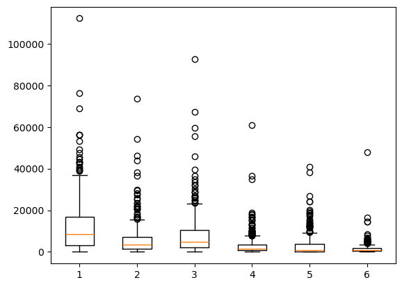

```python
fig, ax = plt.subplots()

ax.boxplot(data)

plt.show()
```

We can see that there are many outliers in each of the categories. We will leave these outliers in for now and come back to it if it were to cause issues.

#### Pairplot:

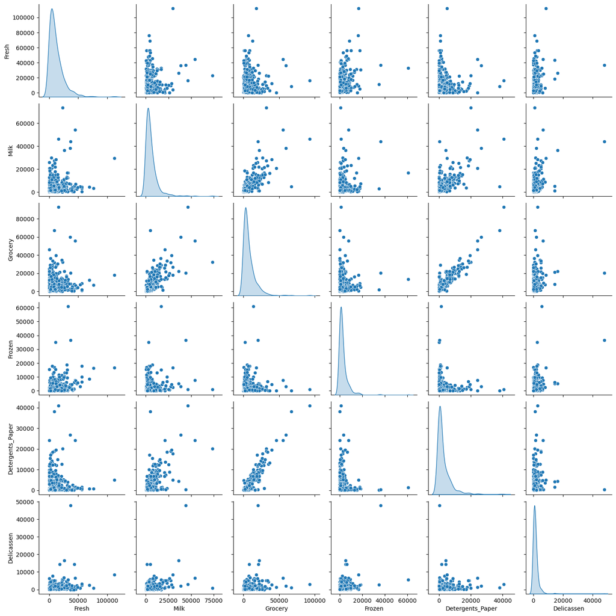

```python
sns.pairplot(data, diag_kind = 'kde')
```

We can see from the pairplot that some variables seem to be correlated. For example, grocery and detergents_paper seem to have some correlation. Let's check this using a correlation matrix.

#### Correlation Matrix:

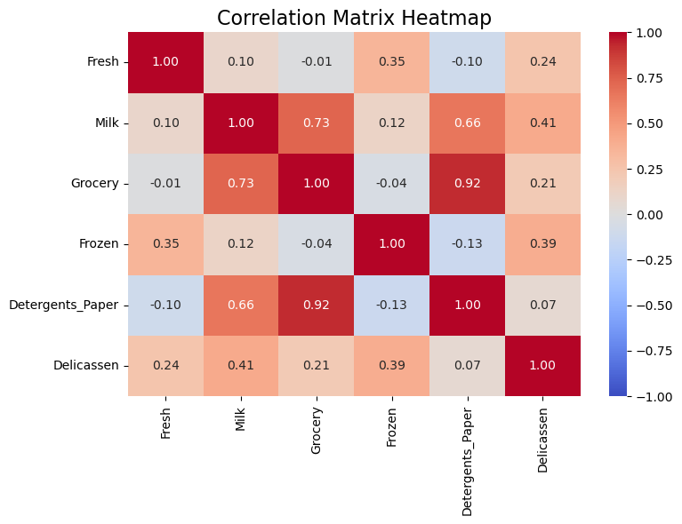

```python
correlation_matrix = data.corr()

plt.figure(figsize=(8, 6))
ax = sns.heatmap(
    correlation_matrix,
    annot=True,
    fmt='.2f',
    cmap='coolwarm',
    vmin=-1, vmax=1
)

plt.title('Correlation Matrix Heatmap', fontsize=16)
plt.tight_layout()
plt.show()
```

From this heatmap, there are a few strong positive correlations seen. The first one was the one we suspected before which was grocery and detergents_paper at a correlation of 0.92. The other correlations that stand out are those of milk and grocery and of milk and detergents_paper with a correlation of 0.73 and 0.66 respectively.

Those three categories (grocery, detergents_paper, milk) seem to be highly correlated. We can potentially combine these features using PCA since they provide similar information. This will be explored later on in this project.

## Data Modeling

### Kmeans Clustering

#### Testing out which n_clusters would be best to use:

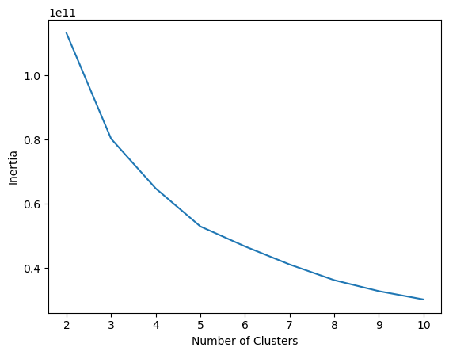

```python
sum_of_squares = []

k_values = range(2, 11)

for k in k_values:
    kmeans = KMeans(n_clusters=k, random_state=42)
    kmeans.fit(data)
    sum_of_squares.append(kmeans.inertia_)

plt.plot(k_values, sum_of_squares)
plt.xlabel("Number of Clusters")
plt.ylabel("Inertia")

plt.show()
```

5 clusters will be used since that is the point where the rate of decrease in inertia slows down

```python
kmeans = KMeans(n_clusters = 5, init='k-means++',  random_state = 42)

y_kmeans = kmeans.fit_predict(data)

data['Cluster'] = y_kmeans
```

```python
data
```

|  | Fresh | Milk | Grocery | Frozen | Detergents_Paper | Delicassen | Cluster |
| --- | --- | --- | --- | --- | --- | --- | --- |
| 0 | 12669 | 9656 | 7561 | 214 | 2674 | 1338 | 1 |
| 1 | 7057 | 9810 | 9568 | 1762 | 3293 | 1776 | 1 |
| 2 | 6353 | 8808 | 7684 | 2405 | 3516 | 7844 | 1 |
| 3 | 13265 | 1196 | 4221 | 6404 | 507 | 1788 | 1 |
| 4 | 22615 | 5410 | 7198 | 3915 | 1777 | 5185 | 0 |
| ... | ... | ... | ... | ... | ... | ... | ... |
| 435 | 29703 | 12051 | 16027 | 13135 | 182 | 2204 | 0 |
| 436 | 39228 | 1431 | 764 | 4510 | 93 | 2346 | 3 |
| 437 | 14531 | 15488 | 30243 | 437 | 14841 | 1867 | 4 |
| 438 | 10290 | 1981 | 2232 | 1038 | 168 | 2125 | 1 |
| 439 | 2787 | 1698 | 2510 | 65 | 477 | 52 | 1 |

440 rows × 7 columns

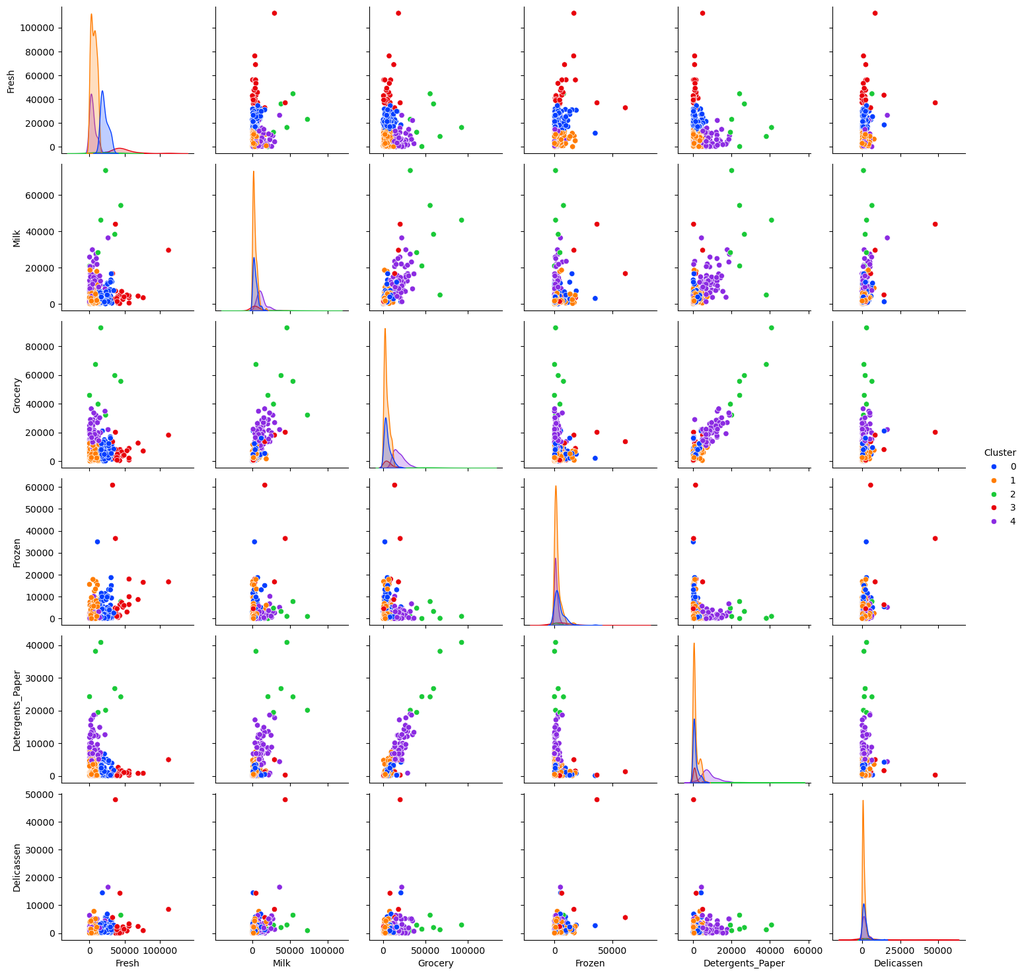

```python
sns.pairplot(data, hue='Cluster', palette = 'bright')
```

After looking at the pairplot that specifies clusters, we can see that cluster number 2 (the green one) seems to hold what seem to be outliers. We will remove these outliers and run KMeans clustering again.

```python
data2 = pd.read_csv("Wholesale.csv")
```

```python
data2 = data2.drop(['Channel', 'Region'], axis = 1)
```

```python
def outliers(data, column):
    q1 = data[column].quantile(0.25)
    q3 = data[column].quantile(0.75)
    IQR = q3 - q1
    lower_bound = q1 - 1.5 * IQR
    upper_bound = q3 + 1.5 * IQR

    def clip_value(x):
        if x < lower_bound:
            return lower_bound
        elif x > upper_bound:
            return upper_bound
        else:
            return x

    data[column] = data[column].apply(clip_value)

outliers(data2, 'Fresh')
outliers(data2, 'Milk')
outliers(data2, 'Grocery')
outliers(data2, 'Frozen')
outliers(data2, 'Detergents_Paper')
outliers(data2, 'Delicassen')
```

#### Testing out which n_clusters would be best to use:

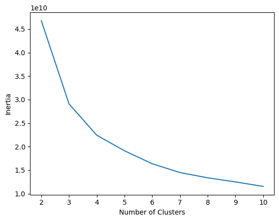

```python
sum_of_squares = []

k_values = range(2, 11)

for k in k_values:
    kmeans = KMeans(n_clusters=k, random_state=42)
    kmeans.fit(data2)
    sum_of_squares.append(kmeans.inertia_)

plt.plot(k_values, sum_of_squares)
plt.xlabel("Number of Clusters")
plt.ylabel("Inertia")

plt.show()
```

4 clusters will be used since that is the point where the rate of decrease in inertia slows down.

```python
kmeans = KMeans(n_clusters = 4, init='k-means++',  random_state = 42)

kmeans.fit(data2)

y_kmeans = kmeans.predict(data2)

data2['Cluster_No_Outliers'] = y_kmeans
```

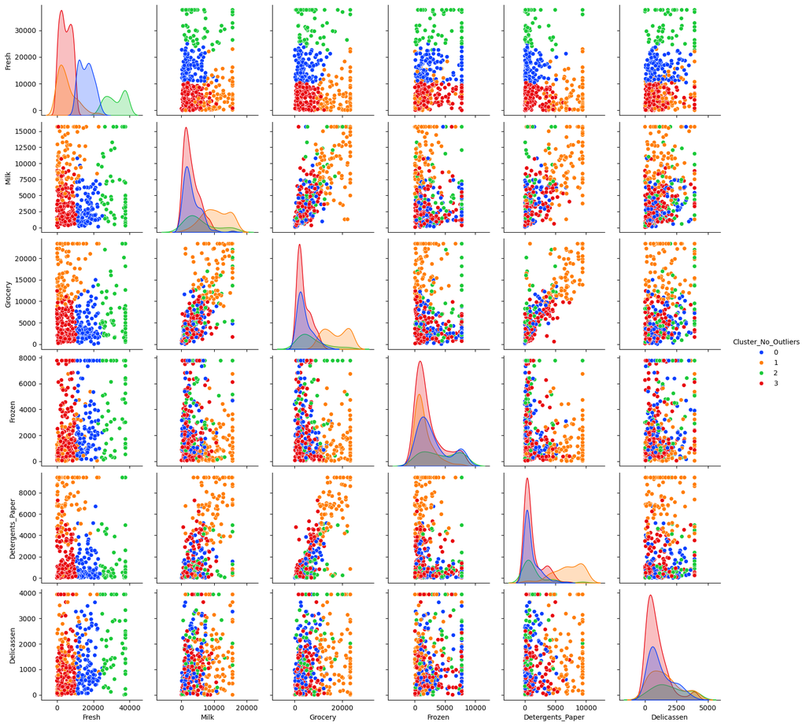

```python
sns.pairplot(data2, hue='Cluster_No_Outliers', palette = 'bright')
```

```python
cluster_profiles = data2.groupby('Cluster_No_Outliers').mean()
cluster_stds = data2.groupby('Cluster_No_Outliers').std()

print(cluster_profiles)
print(cluster_stds)
```

```
                            Fresh          Milk       Grocery       Frozen  \
Cluster_No_Outliers
0                    16051.205357   3135.813616   4211.589286  2988.859375
1                     5331.893617  10454.450798  17196.140957  1496.428191
2                    32136.810345   5973.515086   7309.012931  4170.017241
3                     4741.261364   3073.790483   3817.880682  2192.274148

                     Detergents_Paper   Delicassen
Cluster_No_Outliers
0                          994.785714  1229.573661
1                         6936.898936  1547.364362
2                         1417.426724  1967.702586
3                         1176.454545   909.451705
                           Fresh         Milk      Grocery       Frozen  \
Cluster_No_Outliers
0                    3763.633078  2524.464860  3150.441587  2531.352938
1                    5111.448153  3937.245330  4905.345002  1538.882840
2                    5122.024937  4808.223223  5915.174661  2841.060439
3                    3072.006036  2492.137013  2790.348628  2210.017535

                     Detergents_Paper   Delicassen
Cluster_No_Outliers
0                         1245.589613   963.527882
1                         2383.035957  1176.131062
2                         2055.702539  1267.507352
3                         1473.393792   872.339683
```

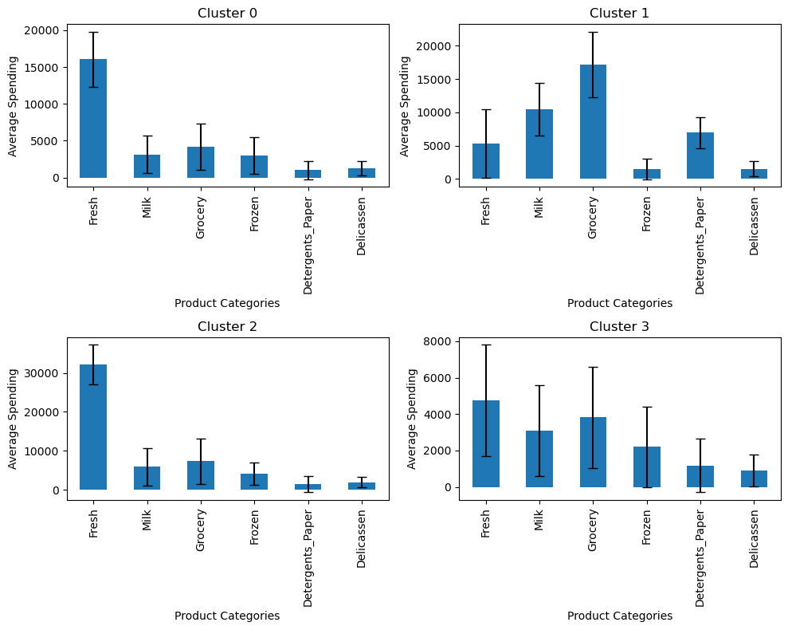

```python
plt.figure(figsize=(10, 8))  # Set the figure size

for i, clus in enumerate(cluster_profiles.index):
    cluster_data = cluster_profiles.loc[clus]
    cluster_std = cluster_stds.loc[clus]

    plt.subplot(2, 2, i + 1)
    cluster_data.plot(kind='bar', yerr=cluster_std, title=f'Cluster {clus}', capsize=4,)
    plt.ylabel('Average Spending')
    plt.xlabel('Product Categories')

plt.tight_layout()
plt.show()
```

This visual provides us a lot of information about each of the clusters:

Cluster 0:

- "Fresh" is the dominant category with significantly higher spending than the rest of the categories
- The rest of the categories have relatively low spending

Cluster 1:

- "Grocery" and "Milk" have high spending among this cluster
- "Frozen" and "Delicassen" spending is notably lower

Cluster 2:

- "Fresh", "Grocery", and "Milk" are the dominating categories but not significantly
- Spending is more balanced across categories compated to the other clusters

If we were to implement this knowledge into a business plan/strategy, I would recommend implementing targeted marketing for each cluster. This would include promoting fresh produce bundles for customers in cluster 0 and 2. I would suggest larger bundles for those in cluster 2 and smaller bundles for those in cluster 0 in order to align the deal with their spending habits. I would also offer bulk discounts in for grocery and milk products for those in cluster 1. For customers in cluster 3, I would suggest diversified offers that focus on combo packages that span across multiple categories.

## PCA

Previously we saw how there were three categories (grocery, detergents_paper, milk) that are highly correlated. We will try to combine these features using PCA since they provide similar information.

```python
data3 = data2.copy()
```

```python
data3
```

|  | Fresh | Milk | Grocery | Frozen | Detergents_Paper | Delicassen | Cluster_No_Outliers |
| --- | --- | --- | --- | --- | --- | --- | --- |
| 0 | 12669.00 | 9656.0 | 7561.000 | 214.00 | 2674.000 | 1338.00 | 0 |
| 1 | 7057.00 | 9810.0 | 9568.000 | 1762.00 | 3293.000 | 1776.00 | 1 |
| 2 | 6353.00 | 8808.0 | 7684.000 | 2405.00 | 3516.000 | 3938.25 | 3 |
| 3 | 13265.00 | 1196.0 | 4221.000 | 6404.00 | 507.000 | 1788.00 | 0 |
| 4 | 22615.00 | 5410.0 | 7198.000 | 3915.00 | 1777.000 | 3938.25 | 0 |
| ... | ... | ... | ... | ... | ... | ... | ... |
| 435 | 29703.00 | 12051.0 | 16027.000 | 7772.25 | 182.000 | 2204.00 | 2 |
| 436 | 37642.75 | 1431.0 | 764.000 | 4510.00 | 93.000 | 2346.00 | 2 |
| 437 | 14531.00 | 15488.0 | 23409.875 | 437.00 | 9419.875 | 1867.00 | 1 |
| 438 | 10290.00 | 1981.0 | 2232.000 | 1038.00 | 168.000 | 2125.00 | 3 |
| 439 | 2787.00 | 1698.0 | 2510.000 | 65.00 | 477.000 | 52.00 | 3 |

440 rows × 7 columns

```python
correlated_categories = data3[['Grocery', 'Milk', 'Detergents_Paper']]
scaler = StandardScaler()
scaled = scaler.fit_transform(correlated_categories)
```

```python
#We will start off with one component and add in more if explained variance isn't high enough
pca = PCA(n_components=1)
X_pca = pca.fit_transform(scaled)
```

```python
print(pca.explained_variance_ratio_)
```

```
[0.85634926]
```

1 component described a large portion of the variance therefore we will not add in any more components.

```python
data3['PCA_Component'] = X_pca
data3 = data3.drop(['Grocery', 'Milk', 'Detergents_Paper', 'Cluster_No_Outliers'], axis=1)
```

```python
data3
```

|  | Fresh | Frozen | Delicassen | PCA_Component |
| --- | --- | --- | --- | --- |
| 0 | 12669.00 | 214.00 | 1338.00 | 0.666754 |
| 1 | 7057.00 | 1762.00 | 1776.00 | 0.990650 |
| 2 | 6353.00 | 2405.00 | 3938.25 | 0.736756 |
| 3 | 13265.00 | 6404.00 | 1788.00 | -1.132181 |
| 4 | 22615.00 | 3915.00 | 3938.25 | -0.079148 |
| ... | ... | ... | ... | ... |
| 435 | 29703.00 | 7772.25 | 2204.00 | 1.247962 |
| 436 | 37642.75 | 4510.00 | 2346.00 | -1.498409 |
| 437 | 14531.00 | 437.00 | 1867.00 | 4.173399 |
| 438 | 10290.00 | 1038.00 | 2125.00 | -1.280701 |
| 439 | 2787.00 | 65.00 | 52.00 | -1.230277 |

440 rows × 4 columns

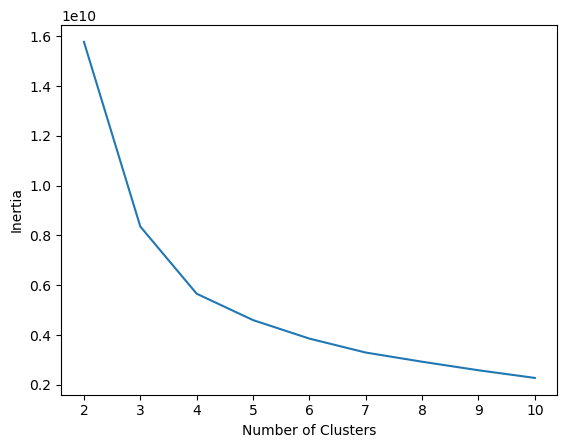

```python
sum_of_squares = []

k_values = range(2, 11)

for k in k_values:
    kmeans = KMeans(n_clusters=k, random_state=42)
    kmeans.fit(data3)
    sum_of_squares.append(kmeans.inertia_)

plt.plot(k_values, sum_of_squares)
plt.xlabel("Number of Clusters")
plt.ylabel("Inertia")

plt.show()
```

We will use 4 clusters since that is where the rate of decrease in inertia slows down.

```python
data3
```

|  | Fresh | Frozen | Delicassen | PCA_Component |
| --- | --- | --- | --- | --- |
| 0 | 12669.00 | 214.00 | 1338.00 | 0.666754 |
| 1 | 7057.00 | 1762.00 | 1776.00 | 0.990650 |
| 2 | 6353.00 | 2405.00 | 3938.25 | 0.736756 |
| 3 | 13265.00 | 6404.00 | 1788.00 | -1.132181 |
| 4 | 22615.00 | 3915.00 | 3938.25 | -0.079148 |
| ... | ... | ... | ... | ... |
| 435 | 29703.00 | 7772.25 | 2204.00 | 1.247962 |
| 436 | 37642.75 | 4510.00 | 2346.00 | -1.498409 |
| 437 | 14531.00 | 437.00 | 1867.00 | 4.173399 |
| 438 | 10290.00 | 1038.00 | 2125.00 | -1.280701 |
| 439 | 2787.00 | 65.00 | 52.00 | -1.230277 |

440 rows × 4 columns

```python
kmeans_pca = KMeans(n_clusters = 4, init='k-means++',  random_state = 42)

pca_kmeans = kmeans_pca.fit_predict(data3)

data3['Cluster_PCA'] = pca_kmeans
```

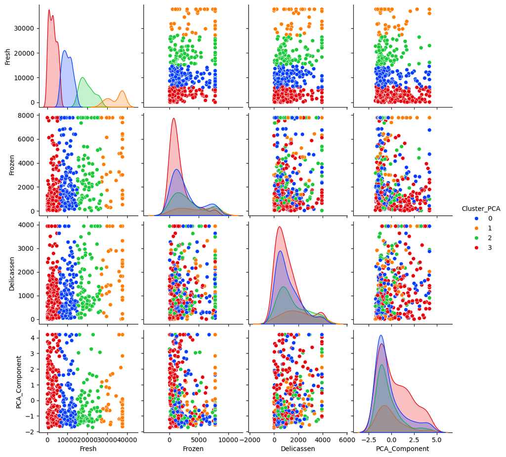

```python
sns.pairplot(data3, hue='Cluster_PCA', palette = 'bright')
```

## Result and Analysis

```python
print("Inertia without PCA:", kmeans.inertia_)
print("Inertia with PCA:", kmeans_pca.inertia_)
```

```
Inertia without PCA: 2274027907.32977
Inertia with PCA: 5657884299.6032
```

We will use silhouette score which measures cluster compactness.

```python
sil_original = silhouette_score(data2, y_kmeans)
sil_pca = silhouette_score(data3, pca_kmeans)

print("Silhouette Score without PCA:", sil_original)
print("Silhouette Score with PCA:", sil_pca)
```

```
Silhouette Score without PCA: 0.35703470092173456
Silhouette Score with PCA: 0.45798488452610064
```

We can see the silhouette score of the model with PCA is higher than that of the model without PCA. This means that clusters produced by the clustering model with PCA resulted in clusters that are more compact therefore the clustering works better after reducing correlated features.

Let's scale up our 'PCA_Components' category:

```python
original_variances = data2[['Fresh', 'Frozen', 'Delicassen']].var()
mean_original_variance = original_variances.mean()

pca_variance = data3['PCA_Component'].var()

scaling_factor = (mean_original_variance / pca_variance) ** 0.5

data3['PCA_Component'] *= scaling_factor

print("Original Features Variance (mean):", mean_original_variance)
print("Scaled PCA Component Variance:", data3['PCA_Component'].var())
```

```
Original Features Variance (mean): 37082844.3270214
Scaled PCA Component Variance: 37082844.32702137
```

Now let's visualize our data:

```python
cluster_profiles = data3.groupby('Cluster_PCA').mean()
cluster_stds = data3.groupby('Cluster_PCA').std()

print(cluster_profiles)
print(cluster_stds)
```

```
                    Fresh       Frozen   Delicassen  PCA_Component
Cluster_PCA
0             9975.356061  2635.376894  1149.554924   -1004.462379
1            34266.613636  4457.369318  1926.653409    -440.939799
2            19832.364706  3163.502941  1520.632353   -1345.115440
3             2721.234637  1621.374302  1070.318436    1487.850266
                   Fresh       Frozen   Delicassen  PCA_Component
Cluster_PCA
0            2330.702784  2358.906216   985.090480    5879.765167
1            3891.692400  2778.378301  1229.415976    5421.536007
2            3396.386735  2583.259836  1160.178114    4959.035103
3            1903.372200  1802.229679   995.564408    6589.518085
```

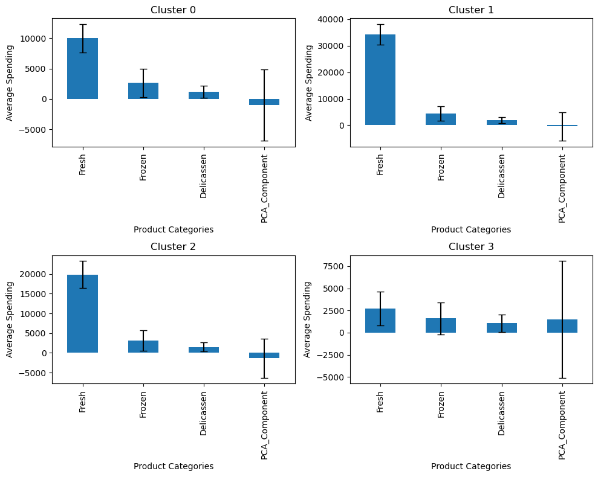

```python
plt.figure(figsize=(10, 8))  # Set the figure size

for i, clus in enumerate(cluster_profiles.index):
    cluster_data = cluster_profiles.loc[clus]
    cluster_std = cluster_stds.loc[clus]

    plt.subplot(2, 2, i + 1)
    cluster_data.plot(kind='bar', yerr=cluster_std, title=f'Cluster {clus}', capsize=4,)
    plt.ylabel('Average Spending')
    plt.xlabel('Product Categories')

plt.tight_layout()
plt.show()
```

#### Analysis:

Observations of the final clusters:

- Cluster 0 retains a strong focus on Fresh products
- Cluster 1 shows extreme spending on Fresh products even more than before PCA
- Cluster 2 is similar to cluster 1 but at a lower magnitude (lower spending)
- Cluster 3 has more balanced spending among the different categories in comparison to the other clusters
- Cluster 3 exhibits a large variance for the PCA component which suggests that this dimension capures significant variance

Overall analysis of the final clusters:

- "Fresh" is the dominant product category across all clusters
  - This is emphasized after PCA was performed
- "Frozen" and "Delicassen" show significantly lower spending levels compared to Fresh

Based off the clusters and the analysis, I would suggest for the business to focus on marketing fresh produce for all customers, bulk discounts for fresh produce for those in cluster 0, large bulk discounts for those in cluster 1 and 2, and diversified offers for those in cluster 3.

## Other Clustering Methods:

What if we want more or less than 4 clusters?

### Hierarchical Clustering:

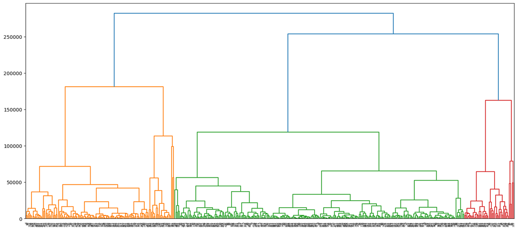

```python
plt.figure(figsize = (18,8))
sc.dendrogram(sc.linkage(data, method='ward'))
plt.show()
```

While 4 clusters seems to be the point at which the rate of decrease of inertia slows down, We might possibly want to create a lower or higher number of clusters.

The dendrogram above groups data points by merging similar clusters until all data points are included in a single cluster at the top of the hierarchy. The height represents the distance (dissimilarity) between the clusters while branches represent the merging of data points.

## Discussion and Conclusion:

### Discussion:

The clustering analysis on the wholesale customer dataset revealed important insights both before and after applying PCA. These results allowed us to identify key spending patterns among clusters and allows us to implement this knowledge into a business plan/strategy. One of the big insights this data provided is the importance of marketing different deals to different customers. While each customer has different needs, this technique increases the likelihood that their needs are met so that they are more likely to shop at that wholesale store.

#### Key Takeaway

This project showed how PCA adds value in distinguishing complex patterns as the scaled PCA components introduced variability that helped capture patterns not visible in the raw data. However, 'Fresh' remained dominance after PCA which suggested that it is a primary driver of variability in this dataset.

#### Challenges:

After performing PCA, the components were initially miniscule to the original features. An additional step of scaling the PCA_Components had to be taken and even then, interpreting it in a real-world context can be challenging since they are abstract representations instead of tangible product categories.

#### Suggestions for Improvement:

**Feature Engineering:**

We can potentially engineer new features such as ratios between categories which can help PCA uncover more subtle patterns and reduce the dominance of a single category (in our case - 'Fresh').

**Alternative Dimensionality Reduction Techniques:**

We can explote t-SNE for dimensionality reduction. This technique can possibly capture patterns that PCA might have missed if the relationships are non-linear between features.

**Clustering Enhancements:**

We can use different clustering methods such as DBSCAN to identify clusters of different shapes that KMeans might miss.

### Conclusion:

This analysis highlights how PCA and KMeans clustering can be powerful tools for uncovering patterns. The pre-PCA clustering provides clear and interpretable insights, while post-PCA clustering offers a higher-level understanding of broader behavioral trends. However, there are associated challenges with PCA that include interpretability, therefore further refinements to the data preprocessing and clustering methodology are needed.

Ultimately, looking at both the pre- and post-PCA approaches allows for detailed insights from the original categories and broader trends from PCA components. This can provide a comprehensive understanding of customer behavior. Future work can focus on exploring advanced dimensionality reduction techniques to better capture the complexity of wholesale customer spending patterns or feature engineering to reduce the dominance of a single category.